# What Makes A Board Game Difficult?

James Hernandez, Jordy Marin Urbina, Sylvain Zong-Naba, and Na Nguyen

2023-11-11

# Introduction

Our group seeks to investigate data on Board games created from 1950-2016 with an emphasis on their complexity with which different variables (from game types and minimum age to number of categories and maximum players) may correlate.

When applicable, we also try to track the changes through each decade by faceting our graphs to give a better visualization.

# Investigating Boardgame Complexity

## Playing Time

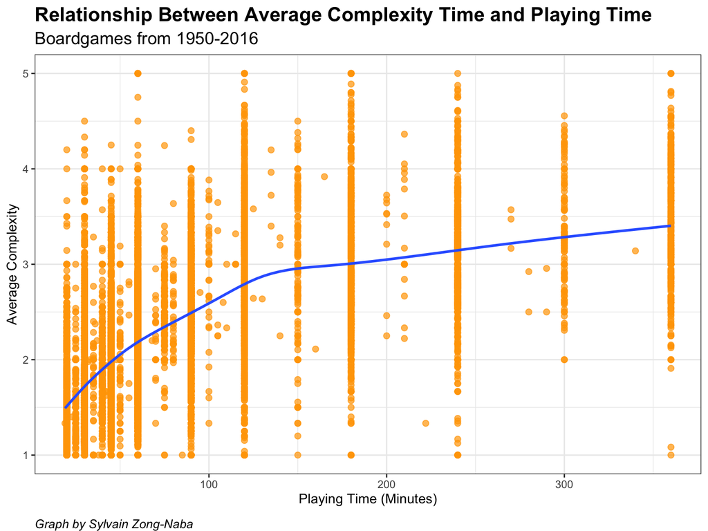

## Number of Categories

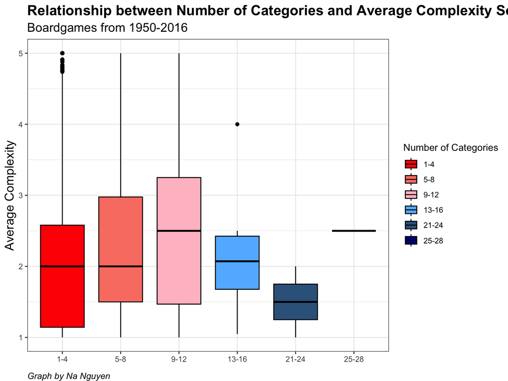

## Base Games vs. Expansion Packs

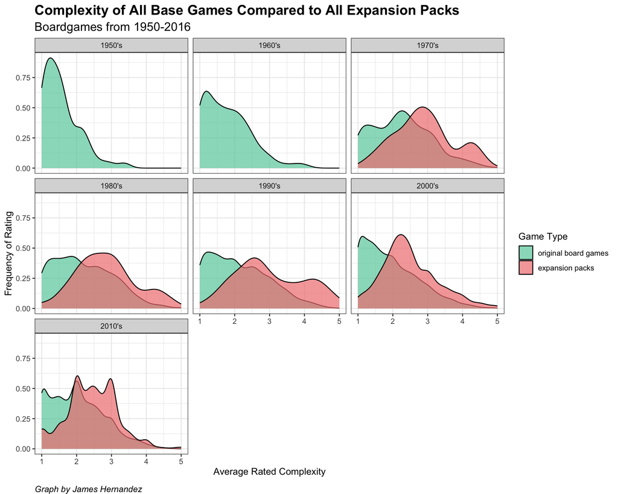

Considering that expansion packs were quite literally adding new material (i.e. rules, lore, strategies, etc.), we wondered whether expansion packs were viewed as more complicated than base games, we decided to create multi-density plots as they would show the frequency of players that rated the game in a specific way for both base games and expansion packs. We filtered out all ratings of 0, as the lowest possible rating was 1. If we had kept that occurrence (0) in the data frame, the graph would imply that many players did not find these games to be complex at all when they really just did not provide a rating. We also noticed that expansion packs became prevalent in the 1970’s; we decided to keep previous data to allow for a temporal analysis of before and after.

We saw that, in general, expansion packs were viewed as more complicated by players. In the 1950s and 1960’s, board games were very skewed to the right (though much more extreme in the former), implying that they were viewed as simple and easy to play. In the 1970’s and forward, ratings began to vary more, but still were viewed as less complicated than that of expansion packs regardless of the decade. The largest subset of players seem to rate base games at a complexity between 1 and 2, implying these games are not very challenging. On the contrary, the largest subset of expansion pack players provided a rating that peaked at roughly 2 and 3. However, while all the density plots for original board games were largely right skewed, expansion packs were still skewed to the right, but only slightly (i.e. 1970’s and 1990’s); there is a much more even distribution. It is interesting to see though how prior to the rise of expansion packs, board games were considered much simpler. It would be interesting to see what factors caused this, and what factors maybe influence expansion packs being more complex.

## Number of Categories ~ Game Type

[figure not shown]

When examining original board games (excluding their expansion versions), we can observe that in the most 2 recent decades, these original board games started to have more categories within a game. Furthermore, the median average complexity score for an original board game with more categories (around 2-3 for games with 9-12 and 13-16 categories), starting from the 1990s, is higher than those with less categories (around 1.8-1.9 for those with less than 9 categories). There is not much data on original games with more than 21 categories, however.

## Card & Science Fiction Games

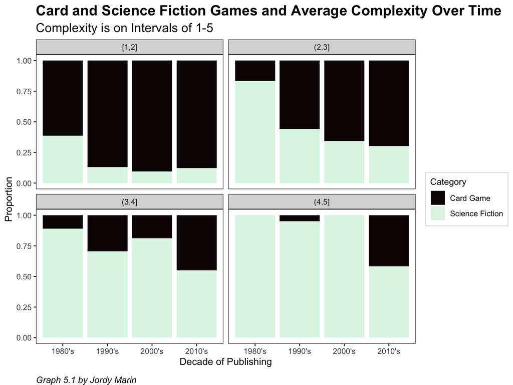

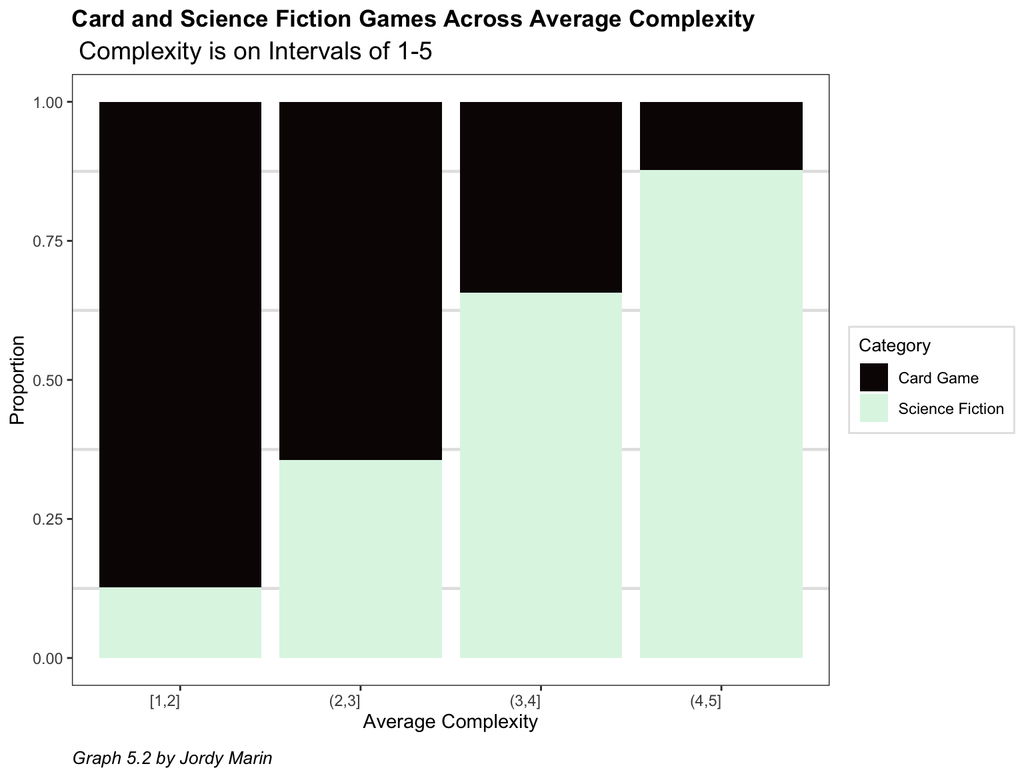

To further explore the previous trends from Figure 5.1, we proceed to dismiss our time exploration. Instead, we focused on examining the conditional proportions of the same two categories Card Game and Science Fiction across all the average complexity scores. Hence, we can observe that overall, Card Games have a higher proportion of the average complexity scores ranging from 1 to 3, as compared to the proportion of Science Fiction Games. Particularly, approximately 87 percent of the Card Games have an average complexity score between 1 and 2 while the other 13 percent corresponds to the Science Fiction Games. Likewise, across the second bar that corresponds to the average complexity score between 2 (not included), approximately 62 percent of the games are Card Games and 38 percent are science fiction games. Nonetheless, on the last two bars that represent the high average scores of 3 (not included), 4, and 5, there seems to be a higher proportion of Science Fiction games in comparison to the card games. For instance, in the last interval of average complexity scores 4 (not included) and 5, approximately more than 80 percent of the games are Science Fiction. Overall, Card Games seem to be more common among the with low scores and science fiction is rated as more complex.

## Maximum Players

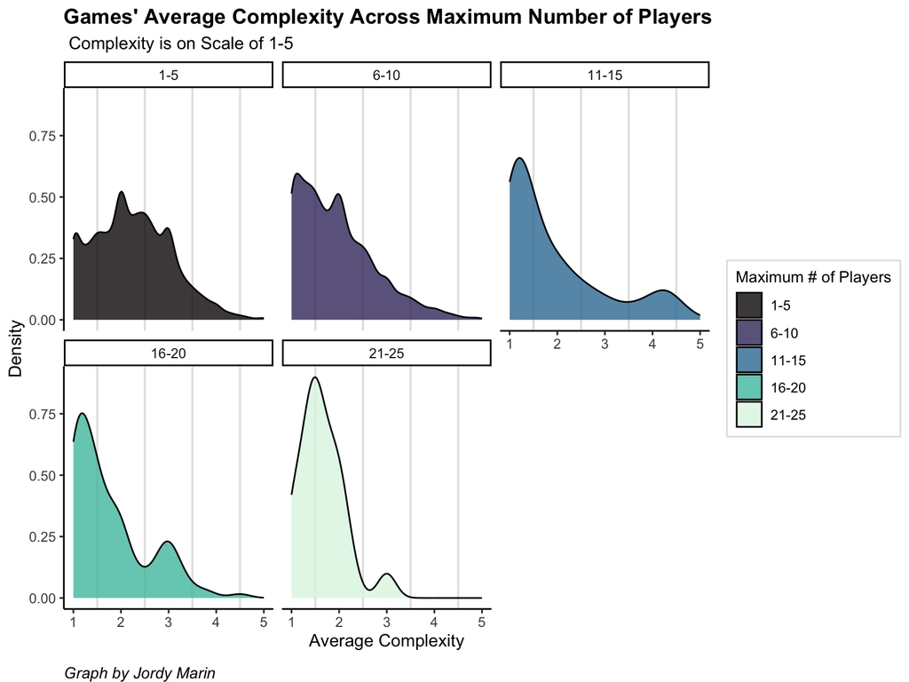

Throughout our data-wrangling process, we only considered games with 25 maximum players or fewer since the higher concentration was in the low numbers of players. From figure 6 we can observe the distribution of the average complexity scores of the games faceted by subgroups of the maximum number of players. From the scores, 1 is the lowest level of average complexity score and 5 is the highest. Within the group of 1-5 maximum number of players, there is a relatively uniform distribution of the average complexity between 1 and 4, having its highest peak at approximately 2. Correspondingly, within the group of 6-10 maximum players, the distribution is right-skewed, having the highest concentration around the lower average complexity scores and with two peaks close to 1 and 2. Additionally, the category of 11-15 maximum players has the highest concentration of around 1-3 average complexity and its peak is between 1-2. However, we can see that there is also some concentration around 3 to 5 average complexity. Lastly, the last two groups of 16-20 and 21-25 maximum players have a similar distribution, having the highest concentration and a peak between 1 to 2. Also, these groups have another concentration around 2.5 to 4 and both peaking at 3. Overall, there seems to be a tendency across all the groups for the maximum number of players and low level of complexity scores.

# Conclusion

For Figure 2, it is observable that the number of categories, to an extent, does correlate with a higher median average complexity score. However, the median for average complexity score seems to decrease once a board game has more than 12 categories.

For Figure 4, drawing from both visualizations 4.1 and 4.2, we can see that although the number of categories does correlate with a higher median average complexity score after the 1990s, the median average complexity score of expansion packs are relatively higher than that of original base games.

From figure 5.1, we can see that Science Fiction games were rated as the most complex across decades from 1980 to 2010 in proportion to Card Games. By looking closely at Figure 5.2 we found that Science Fiction games seem to be rated as more complex (between the 4 and 5 scores).

For Figure 6, we observed that across all five intervals for maximum players, there seems to be a high concentration of the games being rated as 1 and 3 on the score level.

All in all, there are a lot of variables that can fluctuate a board game’s average complexity score. However, there are some that do not significantly correlate with how difficult a game can be. Our project aimed to look at what may or may not influence these results. Yet, there are myriad ways to investigate this topic further that are beyond the scope of the given data.

# Code Appendix

```r
#Loading packages
library(tidyverse)
library(splitstackshape)
library(dbplyr)
library(ggplot2)
library(ggthemes)


#Loading data
boardgames <-read_csv("https://raw.githubusercontent.com/bryandmartin/STAT155/master/docs/Projects/project1_bgdataviz/board_game_raw.csv")

#Saving raw data
write_csv(boardgames,file="./Data/boardgames.csv")
save(boardgames,file="./Data/boardgames.RData")
```

Figure 1

```r
bg <- boardgames %>%
  filter(yearpublished >= 1950 & users_rated >= 25 & average_complexity > 0 & playingtime>15 & playingtime< 400)
```

```r
# Relationship between average rating and average complexity
bg %>%
  ggplot(aes(x = playingtime, y = average_complexity)) +
  geom_point(color="orange",alpha=.7,size=2) +
  theme_bw()+
  geom_smooth( se = FALSE)+
  labs(title = "Relationship Between Average Complexity Time and Playing Time",
       subtitle="Boardgames from 1950-2016",
       x = " Playing Time (Minutes) ",
       y = " Average Complexity ",
       caption = "Graph by Sylvain Zong-Naba" )+
  theme(plot.title=element_text(face="bold",size=16),
        plot.subtitle=element_text(size=14),
        plot.caption=element_text(face="italic",
                              hjust=0,
                              vjust=-1.5,
                              size=10))
```

[output not shown]

```r
#Data visualization
boardgamesFiltered1 %>% ggplot(aes(x=numCat,y=average_complexity, fill=numCat))+
  geom_boxplot(color="black")+
  theme_bw()+
  scale_fill_manual(values = c("red", "salmon", "pink", "steelblue1", "steelblue4","blue4"),labels=c("1-4","5-8","9-12","13-16","21-24","25-28"),name="Number of Categories")+
  scale_x_discrete(labels=c("1-4","5-8","9-12","13-16","21-24","25-28"))+
  labs(title="Relationship between Number of Categories and Average Complexity Score",subtitle="Boardgames from 1950-2016",y="Average Complexity",caption="Graph by Na Nguyen")+
  theme(axis.title.x=element_blank(),plot.title=element_text(face="bold",size=16),axis.title.y=element_text(size=14),plot.subtitle=element_text(size=14),plot.caption=element_text(face="italic",hjust=0,vjust=-1.5,size=10))
```

Figure 3

```r
# Filtering Data
complex_games <- clean_games %>%
  select(game_type,
         average_rating,
         average_complexity,
         yearpublished,
         users_rated) %>%
  filter(average_complexity != "0") %>%
  mutate(decade = dplyr::case_when(
    yearpublished >= 1950 & yearpublished <= 1959 ~ "1950's",
    yearpublished >= 1960 & yearpublished <= 1969 ~ "1960's",
    yearpublished >= 1970 & yearpublished <= 1979 ~ "1970's",
    yearpublished >= 1980 & yearpublished <= 1989 ~ "1980's",
    yearpublished >= 1990 & yearpublished <= 1999 ~ "1990's",
    yearpublished >= 2000 & yearpublished <= 2009 ~ "2000's",
    yearpublished >= 2010 & yearpublished <= 2019 ~ "2010's"))

legend_ttl <- "Game Type"
```

```r
# Data Visualization

ggplot(complex_games,
       aes(x = average_complexity,
           fill = game_type)) +
  geom_density(alpha = 0.7) +
  scale_fill_manual(values = c( "mediumaquamarine", "lightcoral"),
                      labels=c("original board games", "expansion packs"),
                    name = "Game Type") +
  labs(title = "Complexity of All Base Games Compared to All Expansion Packs",
       x = "Average Rated Complexity",
       y = "Frequency of Rating",
       subtitle="Boardgames from 1950-2016",
       caption= "Graph by James Hernandez") +
  theme_bw() +
  theme(plot.title = element_text(
                                  face = "bold",
                                  size = 16),
        plot.subtitle=element_text(size=14),
        plot.caption=element_text(face="italic",hjust=0,vjust=-1.5,size=10)) +
  facet_wrap(~ decade)
```

Figure 4

```r
#Filtering data 4.1
boardgamesFiltered2 <- boardgamesFiltered1 %>%
  filter(game_type!="boardgameexpansion") %>%
  mutate(decades=paste(as.character(floor(yearpublished/10)*10),"s",sep="'"))
```

```r
#Data visualization 4.1
boardgamesFiltered2 %>% ggplot(aes(x=numCat,y=average_complexity, fill=numCat))+
  geom_boxplot(width=.8)+
  theme_bw()+
  scale_fill_brewer(palette = "Set1",
    labels=c("1-4","5-8","9-12","13-16","21-24","25-28")
    )+
  labs(
    title="Relationship between Number of Categories and Average Complexity Score",subtitle="Original Boardgames from 1950-2016",
    y="Average Complexity",
    caption="Graph 4.1 by Na Nguyen",
    fill="Number of Categories"
       )+
  theme(
    axis.title.x=element_blank(),
    axis.text.x=element_blank(),
    plot.title=element_text(face="bold",size=16),
    plot.subtitle=element_text(size=14),
    axis.title.y=element_text(size=14),
    plot.caption=element_text(face="italic",hjust=0,vjust=-1.5,size=10)
    ) +
  facet_grid(~decades)
```

```r
# Filtering data 4.2
boardgamesFiltered3 <- boardgamesFiltered1 %>%
  filter(game_type =="boardgameexpansion") %>%
  mutate(decades=paste(as.character(floor(yearpublished/10)*10),"s",sep="'"))
```

```r
# Data visualization 4.2
boardgamesFiltered3 %>% ggplot(aes(x=numCat,
                                   y=average_complexity,
                                   fill=numCat))+
  geom_boxplot(width=.8)+
  theme_bw()+
  scale_fill_brewer(palette = "Set1",
    labels=c("1-4","5-8","9-12","13-16","21-24","25-28"))+
  labs(
    title="Relationship between Number of Categories and Average Complexity Score",
    subtitle="Expansion Packs from 1950-2016",
    y="Average Complexity",
    caption="Graph 4.2 by James Hernandez",
    fill="Number of Categories")+
  theme(
    axis.title.x=element_blank(),
    axis.text.x=element_blank(),
    plot.title=element_text(face="bold",
                            size=16),
    plot.subtitle=element_text(size=14),
    axis.title.y=element_text(size=14),
    plot.caption=element_text(face="italic",
                              hjust=0,
                              vjust=-1.5,
                              size=10)) +
  facet_grid(~decades)
```

Figure 5

```r
# Filtering the raw data/Data Wrangling 5.1

boardgamestop <- boardgames %>%
  filter(yearpublished >= 1950 & users_rated>= 25 & average_rating > 0 & average_complexity > 0 & maxplayers > 0) %>%
  cSplit("category", sep = ",", direction = "long") %>%
  mutate(Decade = factor(floor(yearpublished/10)*10)) %>%
  mutate(avgComplexityCat = cut(average_complexity, breaks = seq(from = 1, to = 5, by =1), include.lowest = TRUE)) %>%
   group_by(Decade, category, avgComplexityCat) %>%
  filter(category %in% c("Card Game", "Science Fiction"))
boardgamestop$game_type <- boardgamestop$game_type %>%
  str_replace("boardgameexpansion", "Board Game Expansion") %>%
  str_replace("boardgame", "Board Game")
```

```r
#Data Visualization 5.1
boardgamestop %>%
  filter(Decade %in% c(1980, 1990, 2000, 2010)) %>%
ggplot(aes(x=Decade, fill = category)) +
  geom_bar(position = 'fill') +
  facet_wrap(~avgComplexityCat) +
  scale_fill_viridis_d(name = "Category", option = "mako")  +
  theme(axis.text.x = element_text(angle = 0, hjust = 1)) +
  labs(x = "Decade of Publishing", y= "Proportion", title = "Card and Science Fiction Games and Average Complexity Over Time", subtitle = "Complexity is on Intervals of 1-5", caption = "Graph 5.1 by Jordy Marin") +
  scale_x_discrete(labels= c("1980's", "1990's", "2000's", "2010's")) +
  guides(fill=guide_legend(title="Category")) +  theme_bw() +
  theme(panel.grid.major = element_blank(),
        panel.grid.minor.x = element_line(color = "gray89",
                                  size = 0.6,
                                  linetype = 1),
          panel.grid.minor = element_blank(),
        plot.caption=element_text(face="italic",
                              hjust=0,
                              vjust=-1.5,
                              size=10),
         legend.background = element_rect(fill = "white", color = "gray89", size = 0.5, linetype = "solid"),
        plot.title = element_text(face = "bold",size=16),
        plot.subtitle=element_text(size=14),
        legend.title=element_text(size=10)
        )
```

```r
# Filtering Data 5.2

boardgamestop1 <- boardgames %>%
  filter(yearpublished >= 1950 & users_rated>= 25 & average_rating > 0 & average_complexity > 0 & maxplayers > 0) %>%
  cSplit("category", sep = ",", direction = "long") %>%
  mutate(avgComplexityCat = cut(average_complexity, breaks = seq(from = 1, to = 5, by =1), include.lowest = TRUE)) %>%
   group_by(category, avgComplexityCat) %>%
  filter(category %in% c("Card Game", "Science Fiction"))
```

```r
#Data visualization 5.2
ggplot(boardgamestop1, aes(x=avgComplexityCat, fill = category)) + geom_bar(position = 'fill') + theme_bw() +scale_fill_viridis_d(name = "Category", option = "mako")  + theme(axis.text.x = element_text(angle = 0, hjust = 1)) + labs(x = "Average Complexity", y= "Proportion", title = "Card and Science Fiction Games Across Average Complexity", subtitle = " Complexity is on Intervals of 1-5", caption = "Graph 5.2 by Jordy Marin") + guides(fill=guide_legend(title="Category")) +  theme(panel.grid.major = element_blank(),
        panel.grid.minor.x = element_line(color = "gray89",
                                  size = 0.8,
                                  linetype = 1),
        panel.grid.minor.y = element_line(color = "gray89",
                                  size = 0.8,
                                  linetype = 1),
          panel.grid.minor = element_blank(),
        legend.background = element_rect(fill = "white", color = "gray89", size = 0.5, linetype = "solid"),
        plot.caption=element_text(face="italic",
                              hjust=0,
                              vjust=-1.5,
                              size=10),
        plot.subtitle = element_text(size=14),
        plot.title = element_text(face = "bold"),
        legend.title=element_text(size=10)
        )
```

Figure 6

```r
#Filtering Data
 boardgamespop <- boardgames %>%
      filter(yearpublished >= 1950 & users_rated>= 25 & average_rating > 0 & average_complexity > 0, minage <= 20 & maxplayers >0, maxplayers <= 25) %>%
       mutate(maxplayers_Cat = cut(maxplayers, breaks = seq(0, 25, by = 5))) %>%
  mutate(maxplayers_Cat = fct_recode(maxplayers_Cat, "1-5" = "(0,5]", "6-10" = "(5,10]", "11-15" = "(10,15]", "16-20" = "(15,20]", "21-25" = "(20,25]"))
```

```r
#Data visualization
ggplot(boardgamespop, aes(x=average_complexity, fill = maxplayers_Cat)) + facet_wrap(~maxplayers_Cat) +
  geom_density(alpha = 0.8) + xlim(1, 5) + scale_fill_viridis_d(name = "Maximum # of Players", option = "mako", labels=c("1-5","6-10","11-15","16-20","21-25")) +   labs(title = "Games' Average Complexity Across Maximum Number of Players", subtitle = " Complexity is on Scale of 1-5", x = "Average Complexity", y = "Density", caption = "Graph by Jordy Marin") + theme_classic() + theme(panel.grid.major = element_blank(),
        panel.grid.minor.x = element_line(color = "gray89",
                                  size = 0.6,
                                  linetype = 1),
          panel.grid.minor = element_blank(),
        plot.caption = element_text(hjust=1.4),
         legend.background = element_rect(fill = "white", color = "gray89", size = 0.5, linetype = "solid"),
        plot.title = element_text(face = "bold"),
        legend.title=element_text(size=10)
        )
```